# Exploratory analysis of a GEO dataset

Aina Montalban

5/15/2019

# Introduction

The aim of this exercise is to practice the basic elements of Bioconductor and Rmarkdown using a study from the Gene Expression Omnibus Database.

## Summary

This study entitled ‘Genome-wide analysis of uterine natural killer cell gene expression from control diet-fed and high fat diet-fed female mice in early pregnancy’ was done using mice and expression microarrays.

The following description was given: *Analysis of gene expression in uterine natural killer cells purified from control, diet-induced obese and diet-induced obese resistant female mice. The aim of the study is to identify differentially expressed genes and pathways in uterine natural killer cells affected by maternal diet and obesity in pregnancy.*

## Experimental design

Total RNA isolated from FACS-sorted uterine natural killer cells from Gd10.5 pregnancies in 10 control, 6 diet-induced obese and 4 diet-induced obese resistant mice.

## Citation(s)

Baltayeva J, Beristain A

## Study Description

We have two files:

- The *targets* file.
- The *expression matrix* file.

# Read the data

The ExpressionSet object can be created in two ways: (i) using R objects created from the files downloaded and (ii) from the web using geoQUERY.

```r
targets <- read.csv("targets.txt", sep = "")
expressions <- as.matrix(read.delim("expressions.txt", row.names = 1))
class(expressions)
```

```
## [1] "matrix"
```

The package Biobase contains basic structures for microarray data.

```r
require(Biobase)
```

In the following steps, we will create an ExpressionSet using the GEO study mentioned.

### Slot AssayData

The main element, and indeed the only one to be provided to create an ExpressionSet is AssayData. It can be seen as a matrix with as many rows as genes or generically “features” and as many columns as samples or individuals.

```r
myEset <- ExpressionSet(expressions)
class(myEset)
```

```
## [1] "ExpressionSet"
## attr(,"package")
## [1] "Biobase"
```

```r
show(myEset)
```

```
## ExpressionSet (storageMode: lockedEnvironment)
## assayData: 29129 features, 20 samples
##   element names: exprs
## protocolData: none
## phenoData: none
## featureData: none
## experimentData: use 'experimentData(object)'
## Annotation:
```

### Information about covariates

The class AnnotatedDataFrame is intended to contain covariate information.

```r
columnDesc <-  data.frame(labelDescription= c("Sample Names", "Group", "Replicate"))
myAnnotDF <- new("AnnotatedDataFrame", data=targets, varMetadata= columnDesc)
show(myAnnotDF)
```

```
## An object of class 'AnnotatedDataFrame'
##   rowNames: 1 2 ... 20 (20 total)
##   varLabels: sampleName genotype replicate
##   varMetadata: labelDescription
```

```r
# We can add it to to the ExpressionSet.
phenoData(myEset) <- myAnnotDF
```

```r
rownames(pData(myAnnotDF))<-pData(myAnnotDF)$sampleName
myEset <- ExpressionSet(assayData=expressions, phenoData=myAnnotDF)
show(myEset)
```

```
## ExpressionSet (storageMode: lockedEnvironment)
## assayData: 29129 features, 20 samples
##   element names: exprs
## protocolData: none
## phenoData
##   sampleNames: GSM3559494 GSM3559495 ... GSM3559513 (20 total)
##   varLabels: sampleName genotype replicate
##   varMetadata: labelDescription
## featureData: none
## experimentData: use 'experimentData(object)'
## Annotation:
```

## Adding information about features

The number of rows in featureData must match the number of rows in assayData. Row names of featureData must match row names of the matrix in assayData. ALternatively we can simple store the names of the features using a character vector in the slot featureNames.

```r
myGenes <- rownames(expressions)
myEset <- ExpressionSet(assayData=expressions, phenoData=myAnnotDF, featureNames= myGenes)
show(myEset)
```

```
## ExpressionSet (storageMode: lockedEnvironment)
## assayData: 29129 features, 20 samples
##   element names: exprs
## protocolData: none
## phenoData
##   sampleNames: GSM3559494 GSM3559495 ... GSM3559513 (20 total)
##   varLabels: sampleName genotype replicate
##   varMetadata: labelDescription
## featureData: none
## experimentData: use 'experimentData(object)'
## Annotation:
```

### Information about the experiment

The class MIAME was created to add the “Minimum Information About a Microarray Experiment”

```r
myDesc <- new("MIAME", name= "Expression profiling by array",
            lab= "Beristain lab",
            contact= "Alexander G Beristain",
            title="Genome-wide analysis of uterine natural killer cell gene expression from control diet-fed and high fat diet-fed female mice in early pregnancy", url="https://www.ncbi.nlm.nih.gov/geo/query/acc.cgi")
print(myDesc)
```

```
## Experiment data
##   Experimenter name: Expression profiling by array
##   Laboratory: Beristain lab
##   Contact information: Alexander G Beristain
##   Title: Genome-wide analysis of uterine natural killer cell gene expression from control diet-fed and high fat diet-fed female mice in early pregnancy
##   URL: https://www.ncbi.nlm.nih.gov/geo/query/acc.cgi
##   PMIDs:
##   No abstract available.
```

We can also add the annotation, which is the platform.

```r
myEset <- ExpressionSet(assayData=expressions,
                        phenoData=myAnnotDF,
                        experimentData = myDesc,featureNames = myGenes, annotation =    "GPL23038")
show(myEset)
```

```
## ExpressionSet (storageMode: lockedEnvironment)
## assayData: 29129 features, 20 samples
##   element names: exprs
## protocolData: none
## phenoData
##   sampleNames: GSM3559494 GSM3559495 ... GSM3559513 (20 total)
##   varLabels: sampleName genotype replicate
##   varMetadata: labelDescription
## featureData: none
## experimentData: use 'experimentData(object)'
## Annotation: GPL23038
```

# Using objects of class ExpressionSet

## Access Slot values

```r
dim(exprs(myEset))
```

```
## [1] 29129    20
```

```r
class(phenoData(myEset))
```

```
## [1] "AnnotatedDataFrame"
## attr(,"package")
## [1] "Biobase"
```

```r
class(pData(phenoData(myEset)))
```

```
## [1] "data.frame"
```

```r
head(pData(phenoData(myEset)))
```

```
##            sampleName                                     genotype
## GSM3559494 GSM3559494                             Control_diet_fed
## GSM3559495 GSM3559495           High_fat_dietfed_Diet-indued_obese
## GSM3559496 GSM3559496                             Control_diet_fed
## GSM3559497 GSM3559497           High_fat_dietfed_Diet-indued_obese
## GSM3559498 GSM3559498 High_fat_dietfed_Diet-indued_obese_resistant
## GSM3559499 GSM3559499 High_fat_dietfed_Diet-indued_obese_resistant
##            replicate
## GSM3559494     11_1B
## GSM3559495     13_6C
## GSM3559496     14_3A
## GSM3559497    15_10B
## GSM3559498     16_4D
## GSM3559499     17_4C
```

```r
head(pData(myEset))
```

```
##            sampleName                                     genotype
## GSM3559494 GSM3559494                             Control_diet_fed
## GSM3559495 GSM3559495           High_fat_dietfed_Diet-indued_obese
## GSM3559496 GSM3559496                             Control_diet_fed
## GSM3559497 GSM3559497           High_fat_dietfed_Diet-indued_obese
## GSM3559498 GSM3559498 High_fat_dietfed_Diet-indued_obese_resistant
## GSM3559499 GSM3559499 High_fat_dietfed_Diet-indued_obese_resistant
##            replicate
## GSM3559494     11_1B
## GSM3559495     13_6C
## GSM3559496     14_3A
## GSM3559497    15_10B
## GSM3559498     16_4D
## GSM3559499     17_4C
```

## Subsetting

```r
smallEset <- myEset[1:15,c(1:3,6:8)]
dim(exprs(smallEset))
```

```
## [1] 15  6
```

```r
dim(pData(smallEset))
```

```
## [1] 6 3
```

```r
head(pData(smallEset))
```

```
##            sampleName                                     genotype
## GSM3559494 GSM3559494                             Control_diet_fed
## GSM3559495 GSM3559495           High_fat_dietfed_Diet-indued_obese
## GSM3559496 GSM3559496                             Control_diet_fed
## GSM3559499 GSM3559499 High_fat_dietfed_Diet-indued_obese_resistant
## GSM3559500 GSM3559500           High_fat_dietfed_Diet-indued_obese
## GSM3559501 GSM3559501           High_fat_dietfed_Diet-indued_obese
##            replicate
## GSM3559494     11_1B
## GSM3559495     13_6C
## GSM3559496     14_3A
## GSM3559499     17_4C
## GSM3559500     18_2C
## GSM3559501      2_6B
```

```r
all(colnames(exprs(smallEset))==rownames(pData(smallEset)))
```

```
## [1] TRUE
```

```r
youngEset <- myEset[,pData(myEset)$DietType == "Control_diet_fed"]
dim(exprs(youngEset))
```

```
## [1] 29129     0
```

## The GEOquery package

The GEOquery package allows us to to get data from GEO very easily. There is only one command that is need, getGEO.

```r
require(GEOquery)
```

```r
gse <- getGEO("GSE124927")
```

```
## Found 1 file(s)
```

```
## GSE124927_series_matrix.txt.gz
```

```
## File stored at:
```

```
## /tmp/RtmpTdKwLH/GPL23038.soft
```

```r
class(gse)
```

```
## [1] "list"
```

```r
names(gse)
```

```
## [1] "GSE124927_series_matrix.txt.gz"
```

```r
gse[[1]]
```

```
## ExpressionSet (storageMode: lockedEnvironment)
## assayData: 29129 features, 20 samples
##   element names: exprs
## protocolData: none
## phenoData
##   sampleNames: GSM3559494 GSM3559495 ... GSM3559513 (20 total)
##   varLabels: title geo_accession ... tissue:ch1 (37 total)
##   varMetadata: labelDescription
## featureData
##   featureNames: AFFX-BioB-3_at AFFX-BioB-5_at ...
##     TSUnmapped00000064.mm.2 (29129 total)
##   fvarLabels: ID probeset_id ... SPOT_ID_1 (11 total)
##   fvarMetadata: Column Description labelDescription
## experimentData: use 'experimentData(object)'
## Annotation: GPL23038
```

# Data Description

Moreover, we can describe the data we have by doing plots or other commands.

## Dimension and Summary

```r
dim(expressions)
```

```
## [1] 29129    20
```

```r
summary(expressions)
```

```
##    GSM3559494       GSM3559495       GSM3559496       GSM3559497
##  Min.   : 2.089   Min.   : 2.154   Min.   : 2.215   Min.   : 2.034
##  1st Qu.: 4.992   1st Qu.: 5.023   1st Qu.: 5.171   1st Qu.: 5.093
##  Median : 6.516   Median : 6.563   Median : 6.609   Median : 6.580
##  Mean   : 6.744   Mean   : 6.768   Mean   : 6.803   Mean   : 6.757
##  3rd Qu.: 8.328   3rd Qu.: 8.347   3rd Qu.: 8.231   3rd Qu.: 8.258
##  Max.   :13.867   Max.   :13.879   Max.   :14.024   Max.   :13.891
##    GSM3559498       GSM3559499       GSM3559500       GSM3559501
##  Min.   : 2.229   Min.   : 2.329   Min.   : 2.116   Min.   : 2.184
##  1st Qu.: 4.996   1st Qu.: 5.057   1st Qu.: 5.075   1st Qu.: 4.994
##  Median : 6.498   Median : 6.512   Median : 6.533   Median : 6.531
##  Mean   : 6.744   Mean   : 6.755   Mean   : 6.773   Mean   : 6.763
##  3rd Qu.: 8.321   3rd Qu.: 8.258   3rd Qu.: 8.258   3rd Qu.: 8.379
##  Max.   :13.986   Max.   :13.795   Max.   :13.862   Max.   :14.028
##    GSM3559502       GSM3559503       GSM3559504       GSM3559505
##  Min.   : 2.128   Min.   : 2.169   Min.   : 2.184   Min.   : 2.065
##  1st Qu.: 4.847   1st Qu.: 4.809   1st Qu.: 4.831   1st Qu.: 4.791
##  Median : 6.404   Median : 6.389   Median : 6.451   Median : 6.363
##  Mean   : 6.701   Mean   : 6.662   Mean   : 6.683   Mean   : 6.645
##  3rd Qu.: 8.392   3rd Qu.: 8.327   3rd Qu.: 8.354   3rd Qu.: 8.308
##  Max.   :13.981   Max.   :14.092   Max.   :14.069   Max.   :14.034
##    GSM3559506       GSM3559507       GSM3559508       GSM3559509
##  Min.   : 2.156   Min.   : 2.116   Min.   : 2.124   Min.   : 2.131
##  1st Qu.: 4.989   1st Qu.: 4.793   1st Qu.: 4.782   1st Qu.: 4.795
##  Median : 6.543   Median : 6.361   Median : 6.346   Median : 6.360
##  Mean   : 6.742   Mean   : 6.657   Mean   : 6.666   Mean   : 6.663
##  3rd Qu.: 8.322   3rd Qu.: 8.366   3rd Qu.: 8.411   3rd Qu.: 8.365
##  Max.   :13.911   Max.   :13.986   Max.   :13.963   Max.   :14.078
##    GSM3559510       GSM3559511       GSM3559512       GSM3559513
##  Min.   : 2.156   Min.   : 2.186   Min.   : 2.192   Min.   : 2.264
##  1st Qu.: 4.824   1st Qu.: 4.840   1st Qu.: 5.125   1st Qu.: 4.988
##  Median : 6.442   Median : 6.457   Median : 6.578   Median : 6.495
##  Mean   : 6.697   Mean   : 6.715   Mean   : 6.767   Mean   : 6.730
##  3rd Qu.: 8.416   3rd Qu.: 8.433   3rd Qu.: 8.236   3rd Qu.: 8.291
##  Max.   :14.037   Max.   :14.061   Max.   :13.891   Max.   :13.958
```

## Including Plots

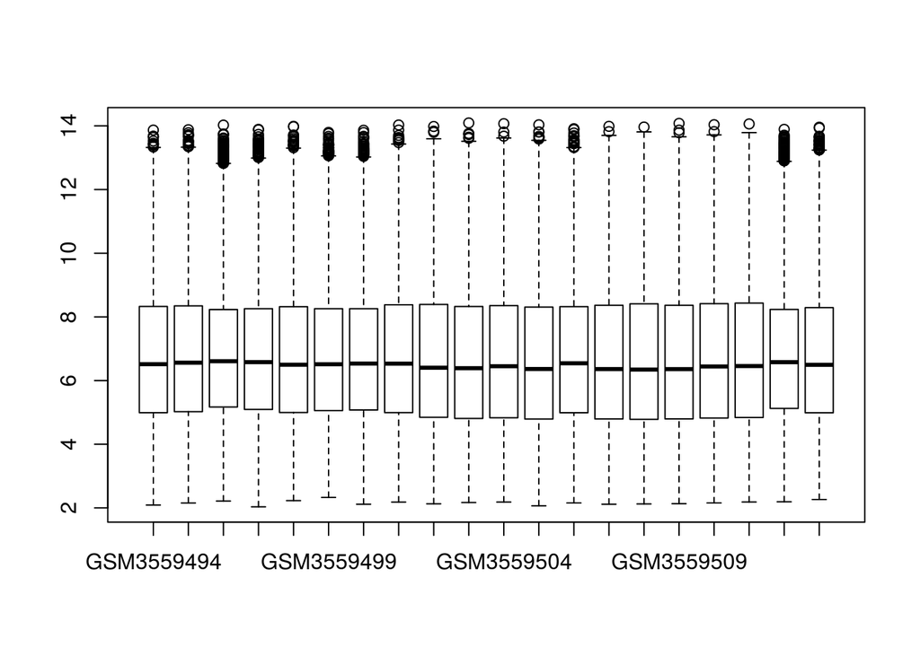

```r
boxplot(expressions)
```